# Untitled

2025-11-17

```r
library(tidyverse)
library(testthat)
```

```r
options(repr.plot.width = 9, repr.plot.height = 6)
theme_set(theme_gray(base_size = 18))
```

## Question 1

*Use the cars dataframe to create a scatter plot with Weight_in_lbs on the x-axis and Horsepower on the y-axis. Color the points by the Origin of the cars.*

```r
cars <- read_csv('../data/cars.csv')
head(cars)
```

```
## # A tibble: 6 × 9
##   Name          Miles_per_Gallon Cylinders Displacement Horsepower Weight_in_lbs
##   <chr>                    <dbl>     <dbl>        <dbl>      <dbl>         <dbl>
## 1 chevrolet ch…               18         8          307        130          3504
## 2 buick skylar…               15         8          350        165          3693
## 3 plymouth sat…               18         8          318        150          3436
## 4 amc rebel sst               16         8          304        150          3433
## 5 ford torino                 17         8          302        140          3449
## 6 ford galaxie…               15         8          429        198          4341
## # ℹ 3 more variables: Acceleration <dbl>, Year <date>, Origin <chr>
```

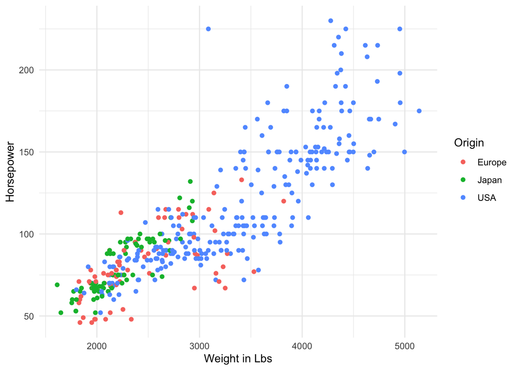

```r
ggplot(data = cars, aes(x = Weight_in_lbs, y = Horsepower, color = Origin )) +
  geom_point() +
  labs(x = 'Weight in Lbs', y = 'Horsepower') +
  theme_minimal()
```

*Let’s use a line plot to visualize how the price of a few common stocks has changed over time. Create a line plot with the stocks’ date on the x-axis and their price on the y-axis. You should colour the lines by the stock symbol so that you can compare the stock development for the different companies.*

```r
stocks <- read_csv('../data/stocks.csv')
glimpse(stocks)
```

```
## Rows: 560
## Columns: 3
## $ symbol <chr> "MSFT", "MSFT", "MSFT", "MSFT", "MSFT", "MSFT", "MSFT", "MSFT",…
## $ date   <date> 2000-01-01, 2000-02-01, 2000-03-01, 2000-04-01, 2000-05-01, 20…
## $ price  <dbl> 39.81, 36.35, 43.22, 28.37, 25.45, 32.54, 28.40, 28.40, 24.53, …
```

```r
head(stocks)
```

```
## # A tibble: 6 × 3
##   symbol date       price
##   <chr>  <date>     <dbl>
## 1 MSFT   2000-01-01  39.8
## 2 MSFT   2000-02-01  36.4
## 3 MSFT   2000-03-01  43.2
## 4 MSFT   2000-04-01  28.4
## 5 MSFT   2000-05-01  25.4
## 6 MSFT   2000-06-01  32.5
```

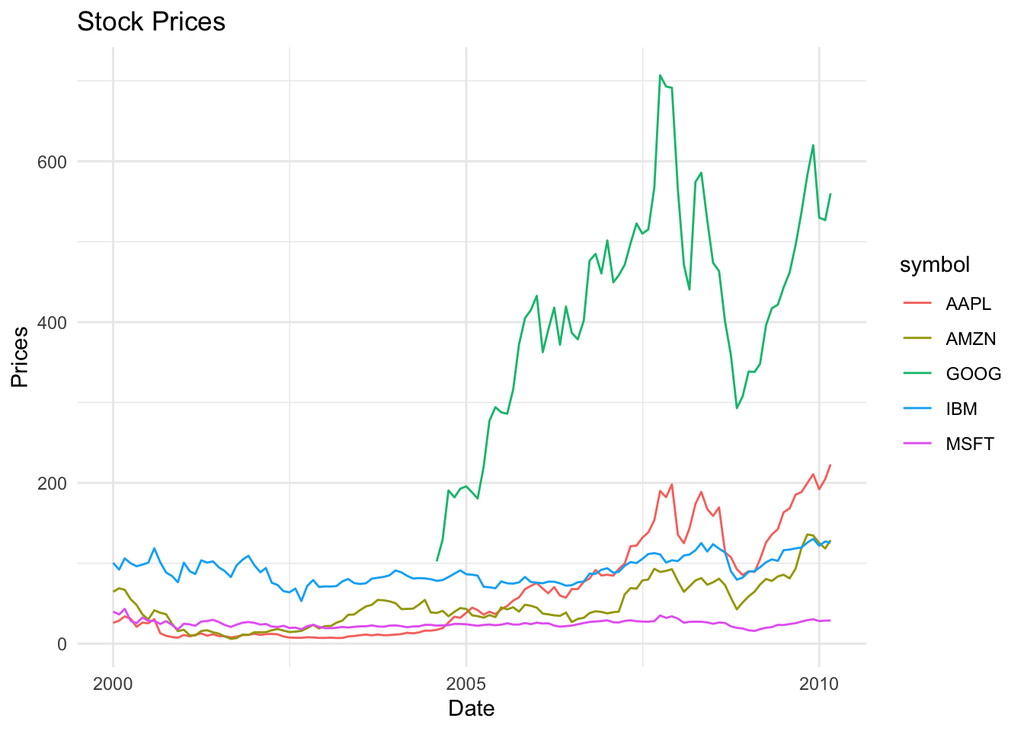

```r
ggplot(data = stocks, aes(x = date, y = price, color = symbol)) +
  geom_line()+
  labs(title = 'Stock Prices', x= 'Date', y = 'Prices')+
  theme_minimal()
```

I have uploaded the 2018 Gapminder data at this URL and assign it a suitablevariable name. Use read_csv from readr to load the data directly from the URL.

*Now let’s create a similar bubble chart to what you saw in the video: Filter the dataframe to only keep observations from a single year, 1962. You can create a new data frame variable or (preferably) perform the filtering directly and pipe it to ggplot. Dates can be matched as strings when filtering. Use a point geom to recreate the appearance of the plot in the video. Encode the proper variables so that children per woman is on the x-axis, life expectancy on the y-axis, and so that the circles’ color corresponds to their region, and the size reflects the population.*

*Don’t worry about getting axis labels and sizes to be exactly like in the video, we will return to this code later in the lab to customize it.*

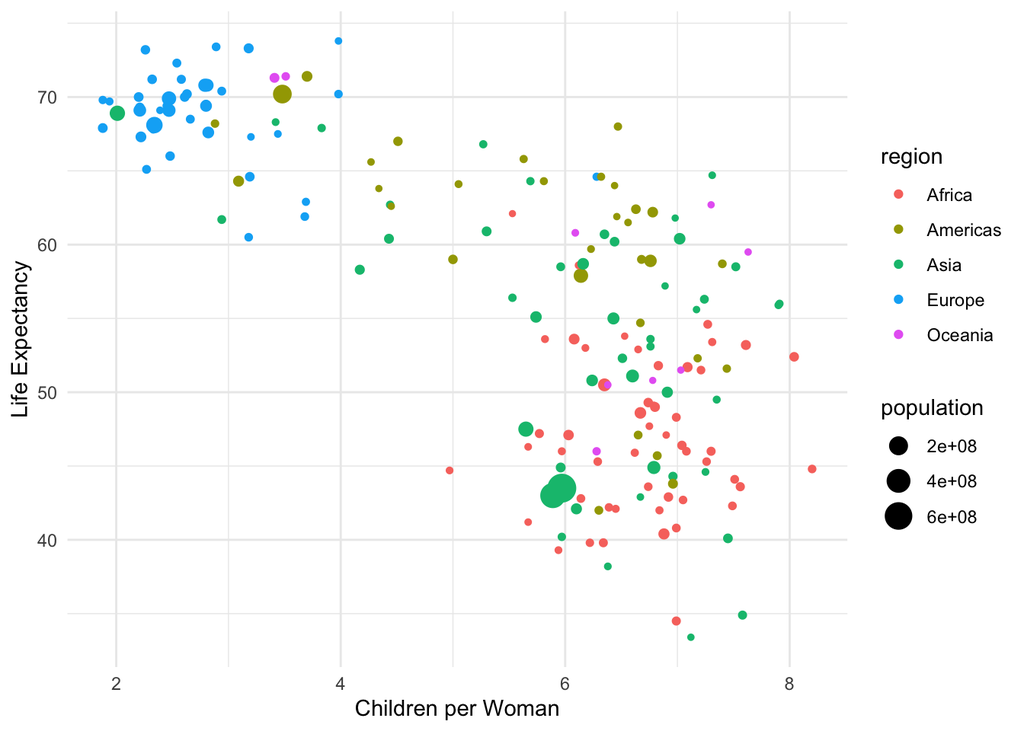

```r
url <- 'https://raw.githubusercontent.com/UofTCoders/workshops-dc-py/master/data/processed/world-data-gapminder.csv'

gap <- read_csv(url) |>
  filter(year == 1962) |>
  ggplot(aes(x = children_per_woman, y = life_expectancy, color = region, size = population)) +
  geom_point()+
  labs(x= 'Children per Woman', y= 'Life Expectancy')+
  theme_minimal()
gap
```

1. Compute a new column in your dataframe (named women_men_school_ratio ) that represents the ratio between the number of years in school for women and men (compute the ratio so that the value 0.5 means half as many for women compared to men rather than the other way around).

2. Filter the dataframe to only contain value from 1970 - 2015, since those are the years where the education data has been recorded. Again you can either create a new variable or perform the filtering as you pass the data to the plotting function.

```r
gap2 <- read_csv(url) |>
  drop_na() |>
  mutate(women_men_school_ratio = years_in_school_women / years_in_school_men) |>
  filter(year >= 1970 & year <=2015) |>
  group_by(income_group)
head(gap2)
```

```
## # A tibble: 6 × 15
## # Groups:   income_group [1]
##   country  year population region sub_region income_group life_expectancy income
##   <chr>   <dbl>      <dbl> <chr>  <chr>      <chr>                  <dbl>  <dbl>
## 1 Afghan…  1970   11100000 Asia   Southern … Low                     45.8   1180
## 2 Afghan…  1971   11400000 Asia   Southern … Low                     45.9   1100
## 3 Afghan…  1972   11700000 Asia   Southern … Low                     45.9   1050
## 4 Afghan…  1973   12000000 Asia   Southern … Low                     46     1150
## 5 Afghan…  1974   12300000 Asia   Southern … Low                     46.1   1180
## 6 Afghan…  1975   12600000 Asia   Southern … Low                     46.3   1210
## # ℹ 7 more variables: children_per_woman <dbl>, child_mortality <dbl>,
## #   pop_density <dbl>, co2_per_capita <dbl>, years_in_school_men <dbl>,
## #   years_in_school_women <dbl>, women_men_school_ratio <dbl>
```